# U.S. Severe Weather Impact Analysis

Aaron Cole

19 January 2016

# 1 Synopsis

- This analysis explores two aspects of the impact of severe weather events in the U.S.
  - Which event types are most harmful with respect to population health.
  - Which event types have the greatest economic consequences.
- The analysis will use historic data to demonstrate which event types have the greatest impact, using data from the Storm Events Database maintained by the U.S. National Oceanic and Atmospheric Administration.
- The analysis will focus on the variables for fatality and injury counts, as well as property and crop damage in USD.
- Based on the number of fatalities, events grouped under the type of wind/storm/tornado have the greatest impact on population health, with 2342 fatalitities, which is 27.2% of the total fatalitities in the sample.
- Based on the number of injuries, events grouped under the type of wind/storm/tornado have the greatest impact on population health, with 27395 injuries, which is 48.8% of the total injuries in the sample.
- The same three event types are the top 3 most impactful on population health when looking at the data based on either fatalities or injuries - wind/storm/tornado, heat, flood.
- Based on the value of damages in USD, flood is the most impactful with a total damage value of $166B, which is 41% of the total value for all damages in the sample. The top 4 of the 11 event types, account for $350B USD of damages, which is 88% of the total.

# 2 Data processing

## 2.1 Load libraries

```r
library(dplyr)
library(lubridate)
```

```r
library(ggplot2)
```

## 2.2 Download data

```r
# Check if the file already exists locally before downloading.
if(file.exists("data.bz2") == FALSE) {
    download.file("https://d396qusza40orc.cloudfront.net/repdata%2Fdata%2FStormData.csv.bz2",
                  "data.bz2",
                  mode = "wb")
}
```

## 2.3 Subsetting

Refer to the [NOAA Storm Events Database Details](http://www.ncdc.noaa.gov/stormevents/details.jsp) webpage for information about the event types being monitored by year. Monitoring for all events started in January 1996 and continues to the present day. Our analysis is interested in examining all events and understanding which event types are most harmful to population health and which event types have the greatest economic consequences. We will exclude data for all years before 1996. The resulting subsetted data represents monitoring of all event types for 1996 onwards and still provides a sizable sample across many years.

```r
# Read the data archive file.
weatherData <- tbl_df(read.csv("data.bz2"))

# Convert the BGN_DATE variable from factor to date.
weatherData$BGN_DATE <- as.Date(weatherData$BGN_DATE, format = "%m/%d/%Y")

# Filter out observations where the BGN_DATE variable is before 1996.
weatherData <- filter(weatherData, BGN_DATE %within% interval(ymd(19960101), Sys.Date()))

# Select only the relevant variables.
weatherData <- weatherData %>%
select(event = EVTYPE,
       fatalities = FATALITIES,
       injuries = INJURIES,
       property_damage = PROPDMG,
       property_damage_function = PROPDMGEXP,
       crop_damage = CROPDMG,
       crop_damage_function = CROPDMGEXP)
```

## 2.4 Property damage value

```r
# Convert to character.
weatherData$property_damage_function <- as.character(weatherData$property_damage_function)

# Convert the values ready for multiplication.
weatherData$property_damage_function[weatherData$property_damage_function == ""] <- "1"
weatherData$property_damage_function[weatherData$property_damage_function == "0"] <- "1"
weatherData$property_damage_function[weatherData$property_damage_function == "K"] <- "1000"
weatherData$property_damage_function[weatherData$property_damage_function == "M"] <- "1000000"
weatherData$property_damage_function[weatherData$property_damage_function == "B"] <- "1000000000"

# Convert to integer.
weatherData$property_damage_function <- as.integer(weatherData$property_damage_function)

# Calculate the new column and drop the old ones.
weatherData <- weatherData %>%
    mutate(property_damage_usd = property_damage * property_damage_function) %>%
    select(-property_damage, -property_damage_function)
```

## 2.5 Crop damage value

```r
# Convert to character.
weatherData$crop_damage_function <- as.character(weatherData$crop_damage_function)

# Convert the values ready for multiplication.
weatherData$crop_damage_function[weatherData$crop_damage_function == ""] <- "1"
weatherData$crop_damage_function[weatherData$crop_damage_function == "0"] <- "1"
weatherData$crop_damage_function[weatherData$crop_damage_function == "K"] <- "1000"
weatherData$crop_damage_function[weatherData$crop_damage_function == "M"] <- "1000000"
weatherData$crop_damage_function[weatherData$crop_damage_function == "B"] <- "1000000000"

# Convert to integer.
weatherData$crop_damage_function <- as.integer(weatherData$crop_damage_function)

# Calculate the new column and drop the old ones.
weatherData <- weatherData %>%
    mutate(crop_damage_usd = crop_damage * crop_damage_function) %>%
    select(-crop_damage, -crop_damage_function)
```

## 2.6 Combine property and crop damage values

```r
# Calculate the new column and drop the old ones.
weatherData <- weatherData %>%
    mutate(damage_usd = property_damage_usd + crop_damage_usd) %>%
    select(-property_damage_usd, -crop_damage_usd)
```

## 2.7 Prepare economic damage data

```r
# Select required columns and filter out zero values.
economicData <- weatherData %>%
    select(event, damage_usd) %>%
    filter(damage_usd > 0)

# Group by event and then sum.
economicData <- economicData %>%
    group_by(event) %>%
    summarise_each(funs(sum))
```

## 2.8 Prepare health data

```r
# Select required columns, groupo by event and then sum.
healthData <- weatherData %>%
    select(event, fatalities, injuries) %>%
    group_by(event) %>%
    summarise_each(funs(sum))

# Filter out events where there were no fatalities or injuries.
healthData <- healthData %>%
    filter(fatalities > 0 | injuries > 0)
```

# 3 Results

## 3.1 Summary

Based on the number of fatalities, events grouped under the type of wind/storm/tornado have the greatest impact on population health, with 2342 fatalitities, which is 27.2% of the total fatalitities in the sample.

Based on the number of injuries, events grouped under the type of wind/storm/tornado have the greatest impact on population health, with 27395 injuries, which is 48.8% of the total injuries in the sample.

The same three event types are the top 3 most impactful on population health when looking at the data based on either fatalities or injuries.

- WIND/STORM/TORNADO.
- HEAT.
- FLOOD.

Based on the value of damages in USD, flood is the most impactful with a total damage value of $166B, which is 41% of the total value for all damages in the sample. The top 4 of the 11 event types, account for $350B USD of damages, which is 88% of the total.

- FLOOD, $166B, 41%.
- HURRICANE/TYPHOON, $87B, 22%.
- RAIN/SURGE, $49B, 12%.
- WIND/STORM/TORNADO, $48B, 12%.

## 3.2 Population health impact based on fatalities

### 3.2.1 Drop injuries variable and filter for fatalities above zero

```r
fatalitiesData <- healthData %>%
    select(-injuries) %>%
    filter(fatalities > 0)
```

### 3.2.2 Add column for fatalities as a percentage of the total

Add a percent column to show the proportion of fatalities for each event, as a percent of the total for all events.

```r
fatalitiesData <- fatalitiesData %>%
    mutate(percent = round((fatalities / sum(fatalitiesData$fatalities) * 100), 3))
```

Examine the data with the quantile function.

```r
quantile(fatalitiesData$percent, seq(0, 1, 0.1))
```

```
##      0%     10%     20%     30%     40%     50%     60%     70%     80%
##  0.0110  0.0110  0.0110  0.0230  0.0230  0.0340  0.1008  0.2750  0.8248
##     90%    100%
##  2.2122 20.5790
```

### 3.2.3 Reducing the number of event types

Between 50% to 55% of the events have a fatalities percent no greater than 0.05%. Subset for these events and check the total sum of the fatalities percent for the subset to verify if the data can be removed without significant impact on the analysis.

```r
arrange(fatalitiesData[fatalitiesData$percent <= 0.05,], desc(percent))
```

```
## Source: local data frame [60 x 3]
##
##                   event fatalities percent
##                  (fctr)      (dbl)   (dbl)
## 1  Hypothermia/Exposure          4   0.046
## 2             ICY ROADS          4   0.046
## 3              Mudslide          4   0.046
## 4             RAIN/SNOW          4   0.046
## 5            ROUGH SURF          4   0.046
## 6         COASTAL FLOOD          3   0.034
## 7         COASTAL STORM          3   0.034
## 8                  Cold          3   0.034
## 9        DRY MICROBURST          3   0.034
## 10          GUSTY WINDS          3   0.034
## ..                  ...        ...     ...
```

```r
round((sum(fatalitiesData[fatalitiesData$percent <= 0.05,]$percent) / sum(fatalitiesData$percent)) * 100, 3)
```

```
## [1] 1.221
```

The 60 events to be removed only represent 1.221% of the total fatalities for all events, removing these 60 event types should not significantly affect our analysis.

```r
fatalitiesData <- fatalitiesData[fatalitiesData$percent > 0.05,]
```

### 3.2.4 Tidy up ready for analysis

```r
# Drop the percent variable.
fatalitiesData <- select(fatalitiesData, -percent)

# Convert the event variable to character.
fatalitiesData$event <- as.character(fatalitiesData$event)

# Tidy up the events into sensible groupings.
fatalitiesData$event[fatalitiesData$event %in% c("EXCESSIVE HEAT",
                                                 "HEAT")] <- "HEAT"

fatalitiesData$event[fatalitiesData$event %in% c("FLASH FLOOD",
                                                 "FLOOD",
                                                 "URBAN/SML STREAM FLD")] <- "FLOOD"

fatalitiesData$event[fatalitiesData$event %in% c("LIGHTNING")] <- "LIGHTNING"

fatalitiesData$event[fatalitiesData$event %in% c("RIP CURRENT",
                                                 "RIP CURRENTS")] <- "RIP CURRENT"

fatalitiesData$event[fatalitiesData$event %in% c("TSTM WIND",
                                                 "THUNDERSTORM WIND",
                                                 "STRONG WIND",
                                                 "HIGH WIND",
                                                 "TROPICAL STORM",
                                                 "MARINE STRONG WIND",
                                                 "MARINE THUNDERSTORM WIND",
                                                 "MARINE TSTM WIND",
                                                 "TORNADO",
                                                 "STRONG WINDS",
                                                 "ROUGH SEAS",
                                                 "WIND")] <- "WIND/STORM/TORNADO"

fatalitiesData$event[fatalitiesData$event %in% c("AVALANCHE",
                                                 "LANDSLIDE")] <- "AVALANCHE/LANDSLIDE"

fatalitiesData$event[fatalitiesData$event %in% c("EXTREME COLD/WIND CHILL",
                                                 "EXTREME COLD",
                                                 "COLD/WIND CHILL",
                                                 "COLD",
                                                 "EXTREME WINDCHILL")] <- "COLD/WINDCHILL"

fatalitiesData$event[fatalitiesData$event %in% c("ICE STORM",
                                                 "BLIZZARD",
                                                 "HEAVY SNOW",
                                                 "COLD AND SNOW",
                                                 "WINTER STORM",
                                                 "WINTER WEATHER",
                                                 "WINTER WEATHER/MIX")] <- "SNOW/ICE"

fatalitiesData$event[fatalitiesData$event %in% c("HEAVY RAIN",
                                                 "HIGH SURF",
                                                 "HEAVY SURF",
                                                 "HEAVY SURF/HIGH SURF",
                                                 "STORM SURGE/TIDE")] <- "RAIN/SURGE/SURF"

fatalitiesData$event[fatalitiesData$event %in% c("WILDFIRE",
                                                 "WILD/FOREST FIRE")] <- "FIRE"

fatalitiesData$event[fatalitiesData$event %in% c("HURRICANE/TYPHOON",
                                                 "HURRICANE",
                                                 "TSUNAMI")] <- "HURRICANE/TYPHOON/TSUNAMI"

fatalitiesData$event[fatalitiesData$event %in% c("DUST STORM")] <- "DUST STORM"

fatalitiesData$event[fatalitiesData$event %in% c("DENSE FOG",
                                                 "FOG")] <- "FOG"

fatalitiesData$event[fatalitiesData$event %in% c("HAIL",
                                                 "TSTM WIND/HAIL")] <- "HAIL"

# Group on event and sum the fatalities value.
fatalitiesData <- fatalitiesData %>%
    group_by(event) %>%
    summarise_each(funs(sum))

# Add back the percentage variable and sort on it.
fatalitiesData <- fatalitiesData %>%
    mutate(percentage = round((fatalities / sum(fatalitiesData$fatalities) * 100), 1)) %>%
    arrange(desc(percentage))
```

### 3.2.5 Plot the fatalities data

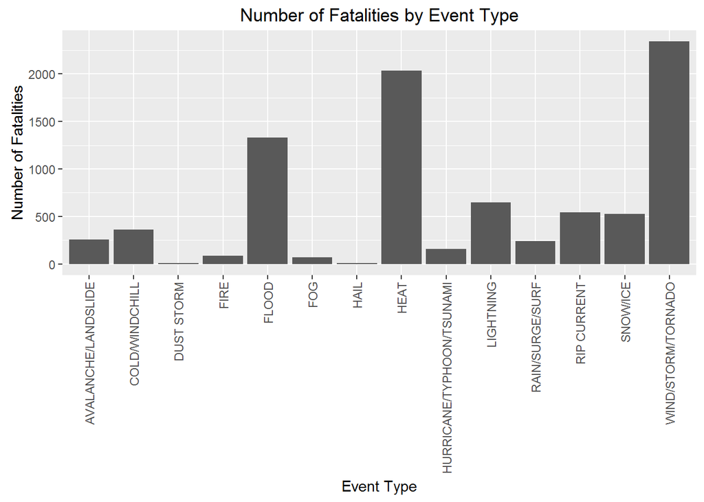

```r
# Create the plot.
p <- ggplot(data = fatalitiesData, aes(x = event, y = fatalities)) +
    geom_bar(stat="identity") +
    xlab("Event Type") +
    ylab("Number of Fatalities") +
    ggtitle("Number of Fatalities by Event Type") +
    theme(axis.text.x = element_text(angle = 90, hjust = 1, vjust = 0.5))

print(p)
```

The plot shows that 3 event types stand out as having significantly higher fatalities.

### 3.2.6 Analysis of fatalities data

```r
sum(fatalitiesData$fatalities)
```

```
## [1] 8624
```

There is a total of 8624 fatalities across all events in our sample.

```r
print(fatalitiesData)
```

```
## Source: local data frame [14 x 3]
##
##                        event fatalities percentage
##                        (chr)      (dbl)      (dbl)
## 1         WIND/STORM/TORNADO       2342       27.2
## 2                       HEAT       2034       23.6
## 3                      FLOOD       1329       15.4
## 4                  LIGHTNING        651        7.5
## 5                RIP CURRENT        542        6.3
## 6                   SNOW/ICE        525        6.1
## 7             COLD/WINDCHILL        365        4.2
## 8        AVALANCHE/LANDSLIDE        260        3.0
## 9            RAIN/SURGE/SURF        239        2.8
## 10 HURRICANE/TYPHOON/TSUNAMI        158        1.8
## 11                      FIRE         87        1.0
## 12                       FOG         69        0.8
## 13                DUST STORM         11        0.1
## 14                      HAIL         12        0.1
```

Ranked by the number of fatalities in descending order, the top 3 events types are considerable higher than the others.

```r
colSums(fatalitiesData[1:3,2:3])
```

```
## fatalities percentage
##     5705.0       66.2
```

The top 3 event types account for 5705 fatalities, which is 66.2% of the total.

## 3.3 Population health impact based on injuries

### 3.3.1 Drop fatalities variable and filter for injuries above zero

```r
injuriesData <- healthData %>%
    select(-fatalities) %>%
    filter(injuries > 0)
```

### 3.3.2 Add column for injuries as a percentage of the total

Add a percent column to show the proportion of injuries for each event, as a percent of the total for all events.

```r
injuriesData <- injuriesData %>%
    mutate(percent = round((injuries / sum(injuriesData$injuries) * 100), 3))
```

Examine the data with the quantile function.

```r
quantile(injuriesData$percent, seq(0, 1, 0.05))
```

```
##       0%       5%      10%      15%      20%      25%      30%      35%
##  0.00200  0.00200  0.00200  0.00200  0.00300  0.00300  0.00400  0.00700
##      40%      45%      50%      55%      60%      65%      70%      75%
##  0.00900  0.01700  0.03250  0.04250  0.06600  0.11800  0.14050  0.26475
##      80%      85%      90%      95%     100%
##  0.50700  0.73300  1.71950  2.76900 35.64800
```

### 3.3.3 Reducing the number of event types

Between 75% to 80% of the events have an injuries percent no greater than 0.3%. Subset for these events and check the total sum of the injuries percent for the subset to verify if the data can be removed without significant impact on the analysis.

```r
arrange(injuriesData[injuriesData$percent <= 0.3,], desc(percent))
```

```
## Source: local data frame [80 x 3]
##
##                   event injuries percent
##                  (fctr)    (dbl)   (dbl)
## 1             AVALANCHE      156   0.269
## 2             HIGH SURF      146   0.252
## 3             DENSE FOG      143   0.247
## 4               TSUNAMI      129   0.223
## 5        TSTM WIND/HAIL       95   0.164
## 6                  WIND       84   0.145
## 7          EXTREME COLD       79   0.136
## 8  URBAN/SML STREAM FLD       79   0.136
## 9            WINTRY MIX       77   0.133
## 10   WINTER WEATHER/MIX       72   0.124
## ..                  ...      ...     ...
```

```r
round((sum(injuriesData[injuriesData$percent <= 0.3,]$percent) / sum(injuriesData$percent)) * 100, 3)
```

```
## [1] 3.245
```

The 80 events to be removed only represent 3.245% of the total injuries for all events, removing these 80 event types should not significantly affect our analysis.

```r
injuriesData <- injuriesData[injuriesData$percent > 0.3,]
```

### 3.3.4 Tidy up ready for analysis

```r
# Drop the percent variable.
injuriesData <- select(injuriesData, -percent)

# Convert the event variable to character.
injuriesData$event <- as.character(injuriesData$event)

# Tidy up the events into sensible groupings.
injuriesData$event[injuriesData$event %in% c("EXCESSIVE HEAT",
                                                 "HEAT")] <- "HEAT"

injuriesData$event[injuriesData$event %in% c("FLASH FLOOD",
                                                 "FLOOD")] <- "FLOOD"

injuriesData$event[injuriesData$event %in% c("LIGHTNING")] <- "LIGHTNING"

injuriesData$event[injuriesData$event %in% c("RIP CURRENT",
                                                 "RIP CURRENTS")] <- "RIP CURRENT"

injuriesData$event[injuriesData$event %in% c("DUST STORM")] <- "DUST STORM"

injuriesData$event[injuriesData$event %in% c("FOG")] <- "FOG"

injuriesData$event[injuriesData$event %in% c("WILDFIRE",
                                                 "WILD/FOREST FIRE")] <- "FIRE"

injuriesData$event[injuriesData$event %in% c("HURRICANE/TYPHOON")] <- "HURRICANE/TYPHOON"

injuriesData$event[injuriesData$event %in% c("HAIL")] <- "HAIL"

injuriesData$event[injuriesData$event %in% c("TSTM WIND",
                                                 "THUNDERSTORM WIND",
                                                 "STRONG WIND",
                                                 "HIGH WIND",
                                                 "TROPICAL STORM",
                                                 "TORNADO")] <- "WIND/STORM/TORNADO"

injuriesData$event[injuriesData$event %in% c("ICE STORM",
                                                 "BLIZZARD",
                                                 "HEAVY SNOW",
                                                 "WINTER STORM",
                                                 "WINTER WEATHER",
                                                 "GLAZE")] <- "SNOW/ICE"

injuriesData$event[injuriesData$event %in% c("HEAVY RAIN")] <- "RAIN"

# Group on event and sum the injuries value.
injuriesData <- injuriesData %>%
    group_by(event) %>%
    summarise_each(funs(sum))

# Add back the percentage variable and sort on it.
injuriesData <- injuriesData %>%
    mutate(percentage = round((injuries / sum(injuriesData$injuries) * 100), 1)) %>%
    arrange(desc(percentage))
```

#### 3.3.4.1 Plot the injuries data

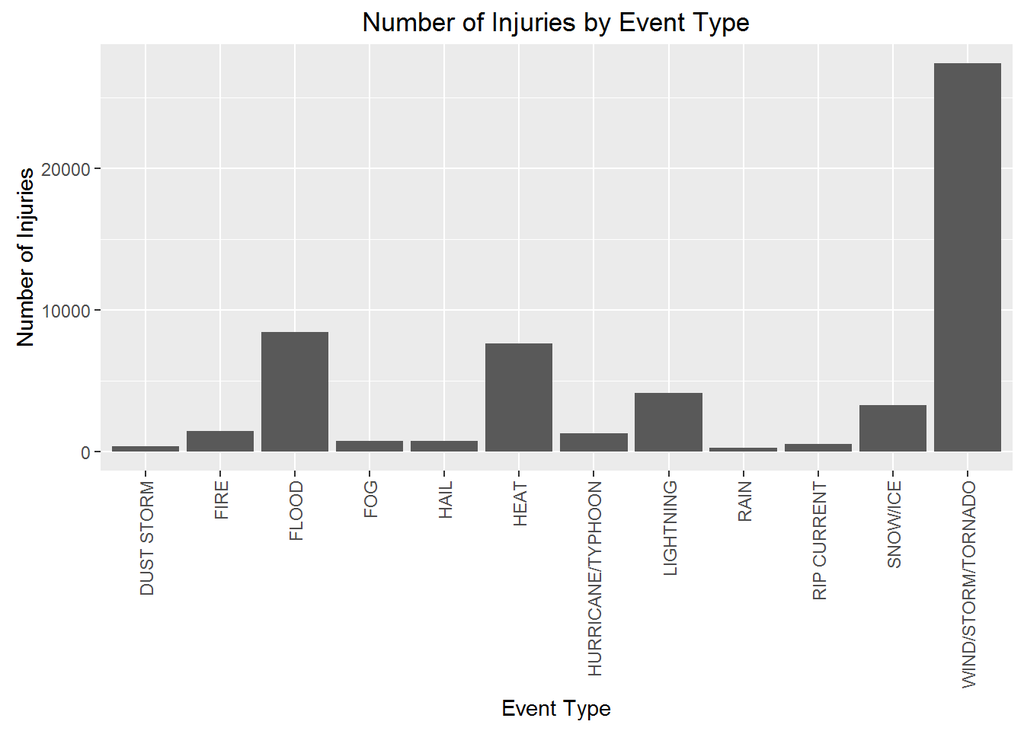

```r
# Create the plot.
p <- ggplot(data = injuriesData, aes(x = event, y = injuries)) +
    geom_bar(stat="identity") +
    xlab("Event Type") +
    ylab("Number of Injuries") +
    ggtitle("Number of Injuries by Event Type") +
    theme(axis.text.x = element_text(angle = 90, hjust = 1, vjust = 0.5))

print(p)
```

The plot shows that 1 event type stands out as having significantly higher injuries.

### 3.3.5 Analysis of injuries data

```r
sum(injuriesData$injuries)
```

```
## [1] 56094
```

There is a total of 56094 injuries across all events in our sample.

```r
print(injuriesData)
```

```
## Source: local data frame [12 x 3]
##
##                 event injuries percentage
##                 (chr)    (dbl)      (dbl)
## 1  WIND/STORM/TORNADO    27395       48.8
## 2               FLOOD     8432       15.0
## 3                HEAT     7613       13.6
## 4           LIGHTNING     4141        7.4
## 5            SNOW/ICE     3248        5.8
## 6                FIRE     1456        2.6
## 7   HURRICANE/TYPHOON     1275        2.3
## 8                 FOG      712        1.3
## 9                HAIL      713        1.3
## 10        RIP CURRENT      503        0.9
## 11         DUST STORM      376        0.7
## 12               RAIN      230        0.4
```

Ranked by the number of injuries in descending order, the top event type is considerably higher than the others.

```r
colSums(injuriesData[1,2:3])
```

```
##   injuries percentage
##    27395.0       48.8
```

The top event type accounts for 27395 injuries, which is 48.8% of the total.

## 3.4 Events with the greatest economic consequences

### 3.4.1 Add new column for event damages as a percentage of the total

Add a new percent column to show the proportion of the damages for each event, as a percent of the total for all events.

```r
economicData <- mutate(economicData, percent = round((damage_usd / sum(economicData$damage_usd) * 100), 1))
```

Examine the data with the quantile function.

```r
quantile(economicData$percent, seq(0, 1, 0.05))
```

```
##     0%     5%    10%    15%    20%    25%    30%    35%    40%    45%
##  0.000  0.000  0.000  0.000  0.000  0.000  0.000  0.000  0.000  0.000
##    50%    55%    60%    65%    70%    75%    80%    85%    90%    95%
##  0.000  0.000  0.000  0.000  0.000  0.000  0.000  0.025  0.300  1.450
##   100%
## 37.100
```

### 3.4.2 Reducing the number of event types

85% of the events have a damage percentage less than or equal to 0.025%. Subset for these events and check the total sum of the damages percent for the subset to verify if the data can be removed without significant impact on the analysis.

```r
arrange(economicData[economicData$percent <= 0.025,], desc(percent))
```

```
## Source: local data frame [158 x 3]
##
##                     event damage_usd percent
##                    (fctr)      (dbl)   (dbl)
## 1      HIGH SURF ADVISORY     200000       0
## 2             FLASH FLOOD      50000       0
## 3               TSTM WIND    8100000       0
## 4         TSTM WIND (G45)       8000       0
## 5     AGRICULTURAL FREEZE   28820000       0
## 6  ASTRONOMICAL HIGH TIDE    9425000       0
## 7   ASTRONOMICAL LOW TIDE     320000       0
## 8               AVALANCHE    3711800       0
## 9           Beach Erosion     100000       0
## 10           BLOWING DUST      20000       0
## ..                    ...        ...     ...
```

```r
round((sum(economicData[economicData$percent <= 0.025,]$damage_usd) / sum(economicData$damage_usd)) * 100, 3)
```

```
## [1] 0.335
```

```r
economicData <- economicData[economicData$percent > 0.025,]
```

### 3.4.3 Tidy up ready for analysis

```r
# Drop the percent variable.
economicData <- select(economicData, -percent)

# Convert the event variable to character.
economicData$event <- as.character(economicData$event)

# Tidy up the events into sensible groupings.
economicData$event[economicData$event %in% c("DROUGHT",
                                             "EXCESSIVE HEAT")] <- "DROUGHT/HEAT"

economicData$event[economicData$event %in% c("EXTREME COLD",
                                             "FROST/FREEZE")] <- "FREEZE/COLD"

economicData$event[economicData$event %in% c("HAIL")] <- "HAIL"

economicData$event[economicData$event %in% c("HEAVY SNOW",
                                             "WINTER STORM",
                                             "BLIZZARD",
                                             "ICE STORM")] <- "SNOW/ICE"

economicData$event[economicData$event %in% c("LANDSLIDE")] <- "LANDSLIDE"

economicData$event[economicData$event %in% c("HEAVY RAIN",
                                             "STORM SURGE",
                                             "STORM SURGE/TIDE")] <- "RAIN/SURGE"

economicData$event[economicData$event %in% c("HIGH WIND",
                                             "STRONG WIND",
                                             "THUNDERSTORM WIND",
                                             "TSTM WIND",
                                             "TROPICAL STORM",
                                             "TORNADO")] <- "WIND/STORM/TORNADO"

economicData$event[economicData$event %in% c("WILD/FOREST FIRE",
                                             "WILDFIRE")] <- "FIRE"

economicData$event[economicData$event %in% c("COASTAL FLOOD",
                                             "FLOOD",
                                             "FLASH FLOOD")] <- "FLOOD"

economicData$event[economicData$event %in% c("HURRICANE",
                                             "HURRICANE/TYPHOON",
                                             "TYPHOON")] <- "HURRICANE/TYPHOON"

economicData$event[economicData$event %in% c("LIGHTNING")] <- "LIGHTNING"

# Group on event and sum the damage value.
economicData <- economicData %>%
    group_by(event) %>%
    summarise_each(funs(sum))

# Add a new variable for the damage in billions of USD for easier plotting.
economicData <- mutate(economicData, damage_usd_billions = round(damage_usd / 1000000000, 2))

# Add back the percentage variable and sort on it.
economicData <- economicData %>%
    mutate(percentage = round((damage_usd / sum(economicData$damage_usd) * 100), 1)) %>%
    select(-damage_usd) %>%
    arrange(desc(percentage))
```

### 3.4.4 Plot the economic damage data

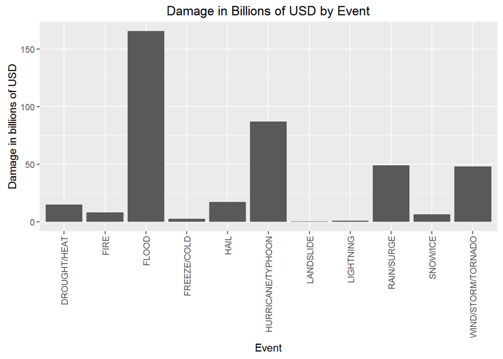

```r
# Create the plot.
p <- ggplot(data = economicData, aes(x = event, y = damage_usd_billions)) +
    geom_bar(stat="identity") +
    xlab("Event") +
    ylab("Damage in billions of USD") +
    ggtitle("Damage in Billions of USD by Event") +
    theme(axis.text.x = element_text(angle = 90, hjust = 1, vjust = 0.5))

print(p)
```

The plot shows that 4 event types stand out as having significantly higher damages.

### 3.4.5 Analysis of the economic damage data

```r
sum(economicData$damage_usd_billions)
```

```
## [1] 400.16
```

There is a total of $400.16B USD of damage across all events in our sample.

```r
print(economicData)
```

```
## Source: local data frame [11 x 3]
##
##                 event damage_usd_billions percentage
##                 (chr)               (dbl)      (dbl)
## 1               FLOOD              165.71       41.4
## 2   HURRICANE/TYPHOON               87.07       21.8
## 3          RAIN/SURGE               49.15       12.3
## 4  WIND/STORM/TORNADO               48.15       12.0
## 5                HAIL               17.07        4.3
## 6        DROUGHT/HEAT               14.91        3.7
## 7                FIRE                8.16        2.0
## 8            SNOW/ICE                6.44        1.6
## 9         FREEZE/COLD                2.41        0.6
## 10          LIGHTNING                0.75        0.2
## 11          LANDSLIDE                0.34        0.1
```

Ranked by the value of the damage in descending order, the top 4 events types are considerably higher than the others.

```r
colSums(economicData[1:4,2:3])
```

```
## damage_usd_billions          percentage
##              350.08               87.50
```

The top 4 event types account for $350.08B USD of damage, which is 87.50% of the total.